# Exam 2

Araynah Dover

2025-04-17

# Exam 2

## Instructions (*Please Read!*)

- This exam is set up so that even if you get stuck on one part there are opportunities to get points on the other parts, so consider jumping ahead if you feel like you aren’t making progress and then come back later if you have time.
- This part of the exam has 70 total points available. Each question is worth 5 points. Partial credit is available, so it is better to at least put *something* rather than leaving a question blank.
- **Important note about using online resources:** This exam is “open internet”. That means that you can look up documentation, google how to accomplish certain tasks, access old ICAs, etc. However, the use of any person-to-person communication or communication with generative AI such as ChatGPT is absolutely not acceptable. If you are seen accessing your email, using ChatGPT, using a messaging service, or accessing any sort of collaborative cloud storage or document software (e.g. Google Documents), you will be at risk of receiving a zero on the exam. If you have any of these open, close them now before starting the exam.
- If you do use any permitted sources to help with a question, you must cite your source in your code or answer.
- Keep your eyes on your screen! This exam is designed to give you the opportunity to show the instructor what you can do and you should hold yourself accountable for maintaining a high level of academic integrity. If any of the instructors observe suspicious behavior, you will, again, risk receiving a zero.
- You are encouraged to check the code chunks and test your code in RStudio.

Import packages here

```r
library(tidyverse)
library(infer)
library(broom)
```

### Section 1 (Inference Problems)

Mercury levels were collected on 43 random specimens of Albacore tuna, the average mercury levels was found to be 0.358 parts per million (ppm) and the standard deviation of mercury level was 0.138 (ppm). The FDA website reports that the average mercury level in all Albacore tuna is 0.391 ppm. The researchers wish to know if the average mercury level in Albacore tuna is different from what is reported on the FDA website. Test the hypothesis at 5% level of significance.

The data “at” is given by:

```r
at <- data.frame(obs=c(1:43),ppm=c(0.35, 0.31, 0.31, 0.46, 0.39, 0.18, 0.47, 0.06, 0.37, 0.52, 0.34, 0.33, 0.42, 0.36, 0.24, 0.43, 0.30, 0.40, 0.55, 0.35, 0.36, 0.14, 0.09, 0.23, 0.42, 0.36, 0.35, 0.30, 0.54, 0.49, 0.12, 0.47, 0.47, 0.43, 0.53, 0.35, 0.36, 0.61, 0.44, 0.18, 0.36, 0.60, 0.12))
```

A glimpse of the data is:

```r
glimpse(at)
```

```
## Rows: 43
## Columns: 2
## $ obs <int> 1, 2, 3, 4, 5, 6, 7, 8, 9, 10, 11, 12, 13, 14, 15, 16, 17, 18, 19,…
## $ ppm <dbl> 0.35, 0.31, 0.31, 0.46, 0.39, 0.18, 0.47, 0.06, 0.37, 0.52, 0.34, …
```

#### Question 1.1

What is the parameter in the study referenced about?

The population mean, μ - the average mercury level in Albacore tuna

#### Question 1.2

What are the null and alternate hypotheses in this study? Be specific.

#### Question 1.3

Update the provided code to generate the null distribution.

```r
# Your code for Q1.3 below
null.dist <- at %>%
  specify(response = ppm) %>%
  hypothesize(null = "point", mu = 0.358) %>%
  generate(reps = 10000, type = "bootstrap") %>%
  calculate(stat = "mean")
```

#### Question 1.4

Plot the null distribution to confirm that it is correct. Draw a line where we expect the center of the null distribution to be. Use the following starter code.

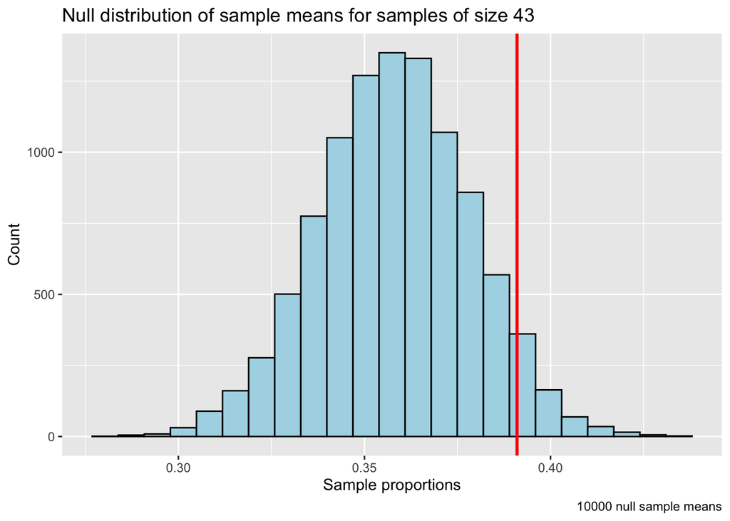

```r
null.dist %>%
  ggplot(mapping = aes(x = stat)) +
  geom_histogram(fill = "lightblue", color = "black", bins = 23) +
  geom_vline(xintercept = 0.391, color = "red", linewidth = 1) +
  labs(x = "Sample proportions", y = "Count",
       title = "Null distribution of sample means for samples of size 43",
       caption = "10000 null sample means")
```

#### Question 1.5

Calculate the p-value of the observed statistic.

```r
null.dist %>%
filter(stat >= 0.391) %>%
summarise(p_value = 2 * n() / nrow(null.dist))
```

```
## # A tibble: 1 × 1
##   p_value
##     <dbl>
## 1   0.108
```

#### Question 1.6

Based on the significance level of 5% and your calculated p-value, what is the conclusion of the hypothesis test?

Compute the 99% confidence interval for the average mercury level in Albacore tuna using the following starter code.

```r
null.dist %>%
  summarise("99%CI_left" = quantile(stat, probs = 0.005),
            "99%CI_right" = quantile(stat, probs = 0.995))
```

```
## # A tibble: 1 × 2
##   `99%CI_left` `99%CI_right`
##          <dbl>         <dbl>
## 1        0.306         0.412
```

#### Question 1.8

Does increasing the confidence interval percentage make the confidence interval wider or narrower? Why?

*It makes it wider reflecting greater confidence in capturing the true avg at the expense of a less precise estimate*

### Section 2 (Linear Models)

The data “mtcars” was extracted from the 1974 Motor Trend US magazine. It comprises of fuel consumption and 10 aspects of automobile design and performance information for a sample of 32 automobiles (1973–74 models). We will perform an analysis to check if the fuel consumption of a car (mpg) can be predicted by the weight (in 1000 lbs) of the car (wt).

```r
glimpse(mtcars)
```

```
## Rows: 32
## Columns: 11
## $ mpg  <dbl> 21.0, 21.0, 22.8, 21.4, 18.7, 18.1, 14.3, 24.4, 22.8, 19.2, 17.8,…
## $ cyl  <dbl> 6, 6, 4, 6, 8, 6, 8, 4, 4, 6, 6, 8, 8, 8, 8, 8, 8, 4, 4, 4, 4, 8,…
## $ disp <dbl> 160.0, 160.0, 108.0, 258.0, 360.0, 225.0, 360.0, 146.7, 140.8, 16…
## $ hp   <dbl> 110, 110, 93, 110, 175, 105, 245, 62, 95, 123, 123, 180, 180, 180…
## $ drat <dbl> 3.90, 3.90, 3.85, 3.08, 3.15, 2.76, 3.21, 3.69, 3.92, 3.92, 3.92,…
## $ wt   <dbl> 2.620, 2.875, 2.320, 3.215, 3.440, 3.460, 3.570, 3.190, 3.150, 3.…
## $ qsec <dbl> 16.46, 17.02, 18.61, 19.44, 17.02, 20.22, 15.84, 20.00, 22.90, 18…
## $ vs   <dbl> 0, 0, 1, 1, 0, 1, 0, 1, 1, 1, 1, 0, 0, 0, 0, 0, 0, 1, 1, 1, 1, 0,…
## $ am   <dbl> 1, 1, 1, 0, 0, 0, 0, 0, 0, 0, 0, 0, 0, 0, 0, 0, 0, 1, 1, 1, 0, 0,…
## $ gear <dbl> 4, 4, 4, 3, 3, 3, 3, 4, 4, 4, 4, 3, 3, 3, 3, 3, 3, 4, 4, 4, 3, 3,…
## $ carb <dbl> 4, 4, 1, 1, 2, 1, 4, 2, 2, 4, 4, 3, 3, 3, 4, 4, 4, 1, 2, 1, 1, 2,…
```

#### Question 2.1

Perform a linear regression to develop a model that predicts `mpg` from `wt`

```r
# Your code for Q2.1 below
model <- lm(mpg ~ wt, data = mtcars)
summary(model)
```

```
##
## Call:
## lm(formula = mpg ~ wt, data = mtcars)
##
## Residuals:
##     Min      1Q  Median      3Q     Max
## -4.5432 -2.3647 -0.1252  1.4096  6.8727
##
## Coefficients:
##             Estimate Std. Error t value Pr(>|t|)
## (Intercept)  37.2851     1.8776  19.858  < 2e-16 ***
## wt           -5.3445     0.5591  -9.559 1.29e-10 ***
## ---
## Signif. codes:  0 '***' 0.001 '**' 0.01 '*' 0.05 '.' 0.1 ' ' 1
##
## Residual standard error: 3.046 on 30 degrees of freedom
## Multiple R-squared:  0.7528, Adjusted R-squared:  0.7446
## F-statistic: 91.38 on 1 and 30 DF,  p-value: 1.294e-10
```

#### Question 2.2

Interpret the value of the slope coefficient in this model. Be very specific.

#### Question 2.3

How much of the variation in the average mpg has been explained by this regression model. Use code to support your answer.

```r
# Your code for Q2.3 below

glance(model)
```

```
## # A tibble: 1 × 12
##   r.squared adj.r.squared sigma statistic  p.value    df logLik   AIC   BIC
##       <dbl>         <dbl> <dbl>     <dbl>    <dbl> <dbl>  <dbl> <dbl> <dbl>
## 1     0.753         0.745  3.05      91.4 1.29e-10     1  -80.0  166.  170.
## # ℹ 3 more variables: deviance <dbl>, df.residual <int>, nobs <int>
```

*R^2 = 0.75 so 75% of the total variation in mpg is explained by the model mt and about 25% is unexplained and attributed to other factors or random variation*

#### Question 2.4

For our model, we get an associated p-value with the slope constant. What are the null and alternate hypotheses associated with this p-value?

*The null hypothesis is 37.28*

*The alternate hypothesis is -5.344*

#### Question 2.5

Now develop a new linear model that aims to predict `mpg` using the input features: `wt`, `disp`, `hp`, and `drat`.

```r
mod.fit <- lm(mpg ~ wt+disp+hp+drat, data = mtcars)
mod.fit %>%
  broom::tidy()
```

```
## # A tibble: 5 × 5
##   term        estimate std.error statistic   p.value
##   <chr>          <dbl>     <dbl>     <dbl>     <dbl>
## 1 (Intercept) 29.1        6.29       4.63  0.0000820
## 2 wt          -3.48       1.08      -3.23  0.00327
## 3 disp         0.00382    0.0108     0.353 0.727
## 4 hp          -0.0348     0.0116    -3.00  0.00576
## 5 drat         1.77       1.32       1.34  0.192
```

#### Question 2.6

Now looking at the p-values of that model, make a parsimonious model considering only the significant feaures. Use a significance level of 0.05.

```r
best_model <- lm(mpg ~ disp, data = mtcars)

glance(best_model)[, c("r.squared", "adj.r.squared")]
```

```
## # A tibble: 1 × 2
##   r.squared adj.r.squared
##       <dbl>         <dbl>
## 1     0.718         0.709
```

## Deliverables

When you’ve finished the exam, upload the RMD and knitted HTML file to D2L in the Exam 2 dropbox. If the code will not knit due to errors, just comment out the code causing the errors and proceed to knit.